# Summarizing Data

## What is this course about?

Basic use of R for reading, manipulating, and plotting data!

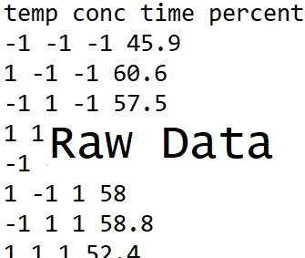

[figure not shown]

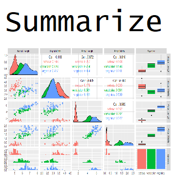

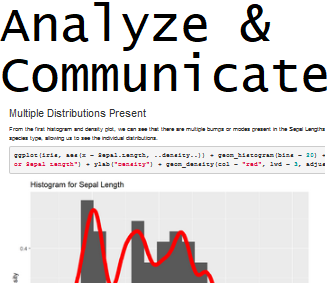

## Where do we start?

- Understand types of data and their distributions
- Numerical summaries

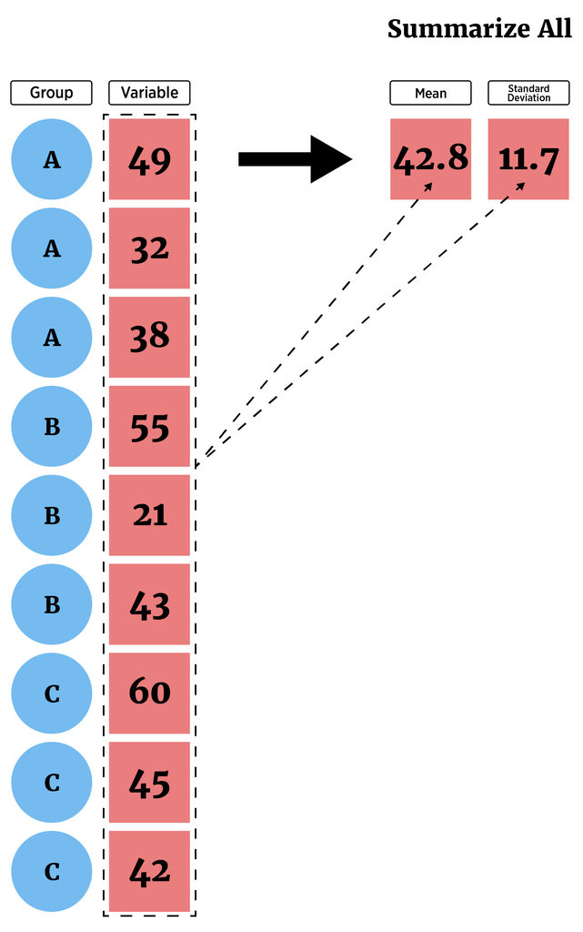

## Where do we start?

- Understand types of data and their distributions
- Numerical summaries (across subgroups)

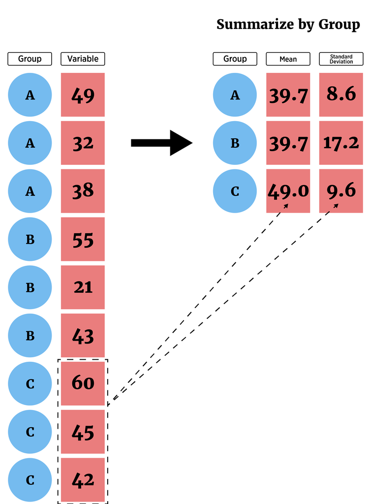

## Where do we start?

- Understand types of data and their distributions
- Numerical summaries (across subgroups)
  - Contingency Tables
  - Mean/Median
  - Standard Deviation/Variance/IQR
  - Quantiles/Percentiles

## Where do we start?

- Understand types of data and their distributions
- Numerical summaries (across subgroups)
  - Contingency Tables
  - Mean/Median
  - Standard Deviation/Variance/IQR
  - Quantiles/Percentiles
- Graphical summaries (across subgroups)
  - Bar plots
  - Histograms
  - Box plots
  - Scatter plots

## Understanding Data

- How to summarize data?
- Depends on data type:
  - Categorical (Qualitative) variable - entries are a label or attribute
  - Numeric (Quantitative) variable - entries are a numerical value where math can be performed

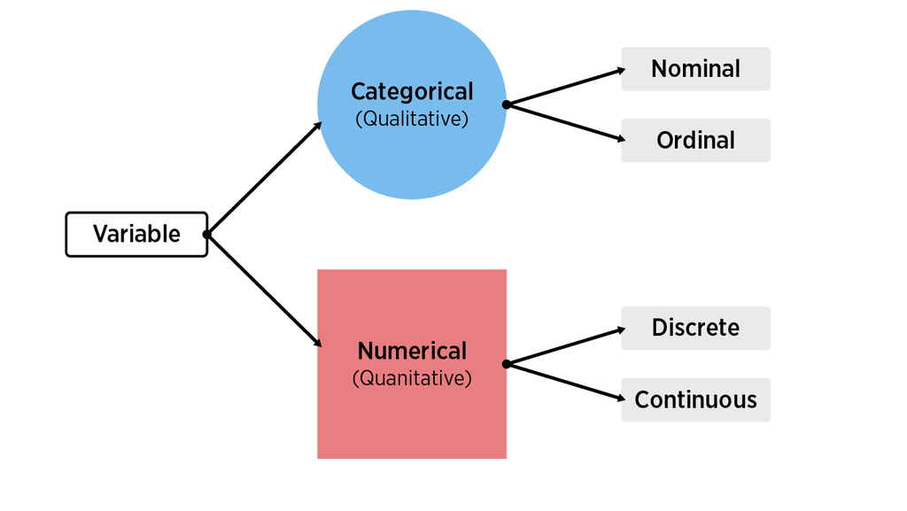

## Categorical Data

Common goal: Describe the **distribution** of the variable

- Distribution = pattern and frequency with which you observe a variable
- Categorical variable - entries are a label or attribute
- Try to describe relative frequency (or count) in each category
- Create contingency tables via `table`

## Contingency tables

- Consider data on titanic passengers in `titanic.csv`

```r
titanicData <- read_csv("../datasets/titanic.csv")
titanicData
```

```
## # A tibble: 1,310 x 14
##   pclass survived name      sex      age sibsp parch ticket  fare cabin embarked
##    <dbl>    <dbl> <chr>     <chr>  <dbl> <dbl> <dbl> <chr>  <dbl> <chr> <chr>
## 1      1        1 Allen, M~ fema~ 29         0     0 24160   211. B5    S
## 2      1        1 Allison,~ male   0.917     1     2 113781  152. C22 ~ S
## 3      1        0 Allison,~ fema~  2         1     2 113781  152. C22 ~ S
## 4      1        0 Allison,~ male  30         1     2 113781  152. C22 ~ S
## 5      1        0 Allison,~ fema~ 25         1     2 113781  152. C22 ~ S
## # ... with 1,305 more rows, and 3 more variables: boat <chr>, body <dbl>,
## #   home.dest <chr>
```

## Contingency tables

- Create **one-way contingency tables** for each of three categorical variables:
  - embarked (where journey started)
  - survived (survive or not)
  - sex (Male or Female)

```r
table(titanicData$embarked)
```

```
##
##   C   Q   S
## 270 123 914
```

```r
table(titanicData$survived)
```

```
##
##   0   1
## 809 500
```

```r
table(titanicData$sex)
```

```
##
## female   male
##    466    843
```

## Two-way contingency tables

- Create **two-way contingency tables** for pairs of categorical variables

```r
table(titanicData$survived,
      titanicData$sex)
```

```
##
##     female male
##   0    127  682
##   1    339  161
```

```r
table(titanicData$survived,
      titanicData$embarked)
```

```
##
##       C   Q   S
##   0 120  79 610
##   1 150  44 304
```

```r
table(titanicData$sex,
      titanicData$embarked)
```

```
##
##            C   Q   S
##   female 113  60 291
##   male   157  63 623
```

## Three-way contingency tables

- Create a **three-way contingency table** for three categorical variables

```r
table(titanicData$sex, titanicData$embarked, titanicData$survived)
```

```
## , ,  = 0
##
##
##            C   Q   S
##   female  11  23  93
##   male   109  56 517
##
## , ,  = 1
##
##
##            C   Q   S
##   female 102  37 198
##   male    48   7 106
```

## Three-way contingency tables

- Create a **three-way contingency table** for three categorical variables (order matters for output!)
- Example of an array! 3 dimensions `[ , , ]`

```r
tab <- table(titanicData$sex, titanicData$embarked, titanicData$survived)

str(tab)
```

```
##  'table' int [1:2, 1:3, 1:2] 11 109 23 56 93 517 102 48 37 7 ...
##  - attr(*, "dimnames")=List of 3
##   ..$ : chr [1:2] "female" "male"
##   ..$ : chr [1:3] "C" "Q" "S"
##   ..$ : chr [1:2] "0" "1"
```

## Conditional contingency tables

- Can obtain **conditional** bivariate info!

[output not shown]

```r
#returns embarked vs survived table for females
tab[1, , ]
```

```
##
##       0   1
##   C  11 102
##   Q  23  37
##   S  93 198
```

## Conditional contingency tables

- Can obtain **conditional** bivariate info!

[output not shown]

```r
#returns embarked vs survived table for males
tab[2, , ]
```

```
##
##       0   1
##   C 109  48
##   Q  56   7
##   S 517 106
```

## Conditional contingency tables

- Can obtain **conditional** bivariate info!

[output not shown]

```r
#returns survived vs sex table for embarked "C"
tab[, 1, ]
```

```
##
##            0   1
##   female  11 102
##   male   109  48
```

## Conditional contingency tables

- Can obtain **conditional** univariate info too!

[output not shown]

```r
#Survived status for males that embarked at "Q"
tab[2, 2, ]
```

```
##  0  1
## 56  7
```

## Numerical summaries: Numeric variables

Numeric variable - entries are a numerical value where math can be performed

**Single variable:** describe the distribution via

- Shape: Histogram, Density plot, …
- Measures of center: Mean, Median, …
- Measures of spread: Variance, Standard Deviation, Quartiles, IQR, …

## Numerical summaries: Numeric variables

Numeric variable - entries are a numerical value where math can be performed

**Single variable:** describe the distribution via

- Shape: Histogram, Density plot, …
- Measures of center: Mean, Median, …
- Measures of spread: Variance, Standard Deviation, Quartiles, IQR, …

**Two Variables:**

- Shape: Scatter plot, …
- Measures of linear relationship: Covariance, Correlation, …

## Numerical summaries: Numeric variables

- Look at carbon dioxide (CO2) uptake data set
  - Response recorded: `uptake` CO2 uptake rates in grass plants
  - Environment manipulated: `Treatment` - chilled/nonchilled
  - Ambient CO2 specified and measured: `conc`

```r
CO2 <- as_tibble(CO2)
CO2
```

```
## # A tibble: 84 x 5
##   Plant Type   Treatment   conc uptake
##   <ord> <fct>  <fct>      <dbl>  <dbl>
## 1 Qn1   Quebec nonchilled    95   16
## 2 Qn1   Quebec nonchilled   175   30.4
## 3 Qn1   Quebec nonchilled   250   34.8
## 4 Qn1   Quebec nonchilled   350   37.2
## 5 Qn1   Quebec nonchilled   500   35.3
## # ... with 79 more rows
```

## Measures of center

Mean & Median

```r
mean(CO2$uptake)
```

```
## [1] 27.2131
```

```r
#note you can easily get a trimmed mean
mean(CO2$uptake, trim = 0.05) #5% trimmed mean
```

```
## [1] 27.25263
```

```r
median(CO2$uptake)
```

```
## [1] 28.3
```

## Measures of spread

Variance, Standard Deviation, Quartiles, & IQR

```r
#quartiles and mean
summary(CO2$uptake)
```

```
##    Min. 1st Qu.  Median    Mean 3rd Qu.    Max.
##    7.70   17.90   28.30   27.21   37.12   45.50
```

```r
var(CO2$uptake)
```

```
## [1] 116.9515
```

```r
sd(CO2$uptake)
```

```
## [1] 10.81441
```

```r
IQR(CO2$uptake)
```

```
## [1] 19.225
```

```r
quantile(CO2$uptake, probs = c(0.1, 0.2))
```

```
##   10%   20%
## 12.36 15.64
```

## Measures of linear relationship

Covariance & Correlation

```r
cov(CO2$conc, CO2$uptake)
```

```
## [1] 1552.687
```

```r
cor(CO2$conc, CO2$uptake)
```

```
## [1] 0.4851774
```

## Numerical summaries: Numeric variables

Usually want summaries for different **subgroups of data**

- Ex: Get similar uptake summaries for each **Treatment**

## Numerical summaries: Numeric variables

Usually want summaries for different **subgroups of data**

- Ex: Get similar uptake summaries for each **Treatment**
- `dplyr` easy to use but can only return one value

## Numerical summaries: Numeric variables

Usually want summaries for different **subgroups of data**

- Ex: Get similar uptake summaries for each **Treatment**
- `dplyr` easy to use (although it can only return one value)

Idea:

- Use `group_by` to create subgroups associated with the data frame
- Use `summarize` to create basic summaries for each subgroup

## Summarizing across groups

- Ex: Get similar uptake summaries for each **Treatment**

```r
CO2 %>%
  group_by(Treatment) %>%
    summarise(avg = mean(uptake), med = median(uptake), var = var(uptake))
```

```
## # A tibble: 2 x 4
##   Treatment    avg   med   var
##   <fct>      <dbl> <dbl> <dbl>
## 1 nonchilled  30.6  31.3  94.2
## 2 chilled     23.8  19.7 118.
```

## Summarizing across groups

- Ex: Get similar uptake summaries for each **Treatment** and **Concentration**

```r
CO2 %>%
  group_by(Treatment, conc) %>%
        summarise(avg = mean(uptake), med = median(uptake), var = var(uptake))
```

```
## # A tibble: 14 x 5
## # Groups:   Treatment [2]
##    Treatment   conc   avg   med    var
##    <fct>      <dbl> <dbl> <dbl>  <dbl>
##  1 nonchilled    95  13.3  12.8   5.75
##  2 nonchilled   175  25.1  24.6  32.6
##  3 nonchilled   250  32.5  32.7  35.1
##  4 nonchilled   350  35.1  34.5  37.4
##  5 nonchilled   500  35.1  33.8  31.9
##  6 nonchilled   675  36.0  35.8  40.2
##  7 nonchilled  1000  37.4  37.6  49.8
##  8 chilled       95  11.2  10.6   8.18
##  9 chilled      175  19.4  19.5  34.7
## 10 chilled      250  25.3  24.2 112.
## 11 chilled      350  26.2  26.4 117.
## 12 chilled      500  26.6  26   131.
## 13 chilled      675  27.9  28.8 120.
## 14 chilled     1000  29.8  30.3 154.
```

## Summarizing across groups

`dplyr` has variations on `summarise` that can be used:

- `summarise_all()` - Apply functions to every column
- `summarise_at()` - Apply functions to specific columns
- `summarise_if()` - Apply functions to all columns of one type

## Summarizing across groups

- Ex: Get similar uptake summaries for each **Treatment**
- Built-in `aggregate()` function more general

## Summarizing across groups

- Ex: Get similar uptake summaries for each **Treatment**
- Built-in `aggregate()` function more general
- Basic use gives response (`x`) and a `list` of variables to group `by`

```r
aggregate(x = CO2$uptake, by = list(CO2$Treatment), FUN = summary)
```

```
##      Group.1   x.Min. x.1st Qu. x.Median   x.Mean x.3rd Qu.   x.Max.
## 1 nonchilled 10.60000  26.47500 31.30000 30.64286  38.70000 45.50000
## 2    chilled  7.70000  14.52500 19.70000 23.78333  34.90000 42.40000
```

## Summarizing across groups

- `aggregate()` is commonly used with `formula` notation!

`uptake ~ Treatment` - is an example of formula notation

- Idea: uptake (LHS) modeled by Treatment levels (RHS)

## Summarizing across groups

- `aggregate()` is commonly used with `formula` notation!

`uptake ~ Treatment` - is an example of formula notation

- Idea: uptake (LHS) modeled by Treatment levels (RHS)

```r
aggregate(uptake ~ Treatment, data = CO2, FUN = summary)
```

[output not shown]

## Summarizing across groups

- `aggregate()` is commonly used with `formula` notation!

`uptake ~ Treatment + conc` model uptake by levels of Treatment and conc

```r
aggregate(uptake ~ Treatment + conc, data = CO2, FUN = summary)
```

```
##     Treatment conc uptake.Min. uptake.1st Qu. uptake.Median uptake.Mean
## 1  nonchilled   95    10.60000       11.47500      12.80000    13.28333
## 2     chilled   95     7.70000        9.60000      10.55000    11.23333
## 3  nonchilled  175    19.20000       20.05000      24.65000    25.11667
## 4     chilled  175    11.40000       15.67500      19.50000    19.45000
## 5  nonchilled  250    25.80000       27.30000      32.70000    32.46667
## 6     chilled  250    12.30000       17.95000      24.20000    25.28333
## 7  nonchilled  350    27.90000       30.45000      34.50000    35.13333
## 8     chilled  350    13.00000       18.15000      26.45000    26.20000
## 9  nonchilled  500    28.50000       31.27500      33.85000    35.10000
## 10    chilled  500    12.50000       18.30000      26.00000    26.65000
## 11 nonchilled  675    28.10000       31.42500      35.80000    36.01667
## 12    chilled  675    13.70000       19.72500      28.80000    27.88333
## 13 nonchilled 1000    27.80000       32.50000      37.60000    37.38333
## 14    chilled 1000    14.40000       20.40000      30.30000    29.78333
##    uptake.3rd Qu. uptake.Max.
## 1        15.40000    16.20000
## 2        13.30000    15.10000
## 3        29.62500    32.40000
## 4        23.32500    27.30000
## 5        36.52500    40.30000
## 6        33.82500    38.10000
## 7        40.65000    42.10000
## 8        34.45000    38.80000
## 9        39.27500    42.90000
## 10       37.07500    38.90000
## 11       40.85000    43.90000
## 12       36.97500    39.60000
## 13       43.15000    45.50000
## 14       40.72500    42.40000
```

## Recap

- Understand types of data and their distributions
- Numerical summaries
  - Contingency Tables: `table`
  - Mean/Median: `mean`, `median`
  - Standard Deviation/Variance/IQR: `sd`, `var`, `IQR`
  - Quantiles/Percentiles: `quantile` for more general quantiles
- Across subgroups with `dplyr::group_by` and `dplyr::summarize` or `aggregate`

## Quick Examples

- Go to the [course files page](https://jbpost2.github.io/Basics-of-R-for-Data-Science-and-Statistics/CourseFiles.html) and try Exercise 9 - Numeric Summaries

## Where are we at?

- Understand types of data and their distributions
- Numerical summaries (across subgroups)
  - Contingency Tables
  - Mean/Median
  - Standard Deviation/Variance/IQR
  - Quantiles/Percentiles
- Graphical summaries (across subgroups)
  - Bar plots (categorical data)
  - Histograms
  - Box plots
  - Scatter plots

## Graphical Summaries

Three major systems for plotting:

- Base R (built-in functions)
- Lattice
- ggplot2 (sort of part of the tidyverse - Cheat Sheet)
  - `ggplot(data = data_frame)` creates a plot instance
  - Add “layers” to the system (geoms or stats)

Great [reference book here!](https://bookdown.org/rdpeng/exdata/plotting-systems.html)

## `ggplot2` Plotting

ggplot2 basics (Cheat Sheet)

- `ggplot(data = data_frame)` creates a plot instance
- Add “layers” to the system (geoms or stats)
  - Creates a visualization of the data

## `ggplot2` Plotting

ggplot2 basics (Cheat Sheet)

- `ggplot(data = data_frame)` creates a plot instance
- Add “layers” to the system (geoms or stats)
  - Creates a visualization of the data
- Modify layer “mapping” args (aes)
  - Ex: size, color, and x, y location(s)
- Coordinate system (mostly use Cartesian plane)
- Optional: Titles, etc.

## `factors`

- factor - special class of vector with a `levels` attribute
- Levels define all possible values for that variable
  - Great for variable like `Day` (Monday, Tuesday, …)
  - Not great for variable like `Name` where new values may come up
- Quite useful with plotting
  - Allows for easy labeling of subgroups

## `factors`

- Consider data on titanic passengers in `titanic.csv`

```r
#convert survival status to a factor
titanicData$survived <- as.factor(titanicData$survived)
levels(titanicData$survived) #R knows it isn't numeric now
```

```
## [1] "0" "1"
```

- Can’t add value unless it is a level

```r
titanicData$survived[1] <- "5"
```

## `factor` levels

- Useful if you want to create better labels (or change the ordering)

```r
levels(titanicData$survived) <- c("Died", "Survived")
levels(titanicData$survived)
```

```
## [1] "Died"     "Survived"
```

## `ggplot2` Plotting: Categorical variables

Categorical variable - entries are a label or attribute

Generally, describe distriubtion using a barplot!

- Barplots via `ggplot + geom_bar`

```r
titanicData <- read_csv("../datasets/titanic.csv")
titanicData$mySurvived <- as.factor(titanicData$survived)
levels(titanicData$mySurvived) <- c("Died", "Survived")
titanicData$myEmbarked <- as.factor(titanicData$embarked)
levels(titanicData$myEmbarked) <- c("Cherbourg", "Queenstown", "Southampton")
titanicData <- titanicData %>% drop_na(mySurvived, sex, myEmbarked)
```

## `ggplot2` barplots

- Barplots via `ggplot + geom_bar`
- Across x-axis we want our categories - specify with `aes(x = ...)`

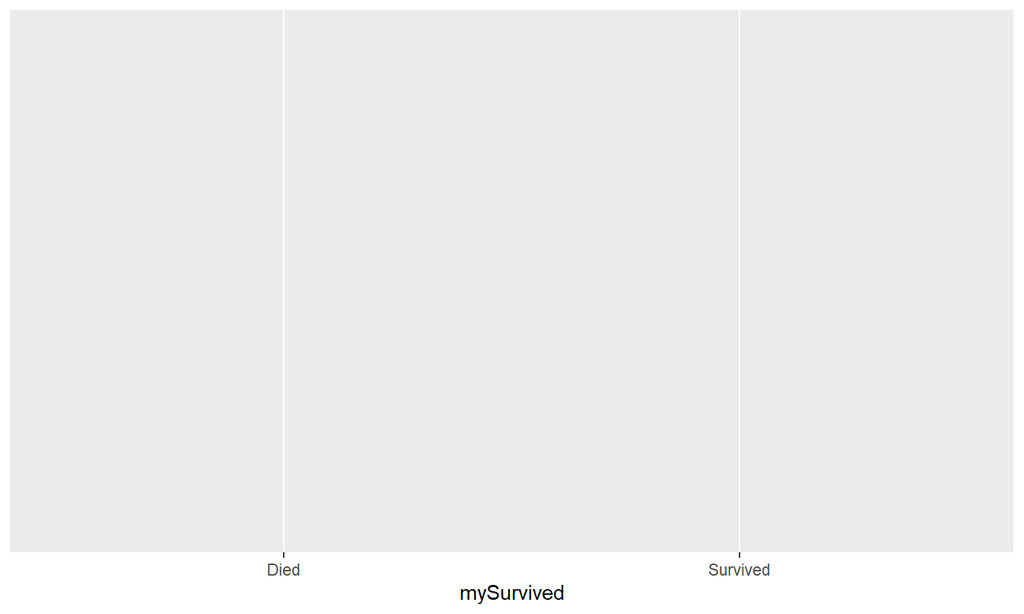

```r
ggplot(data = titanicData, aes(x = mySurvived))
```

## `ggplot2` barplots

- Barplots via `ggplot + geom_bar`
- Must add geom (or stat) layer!

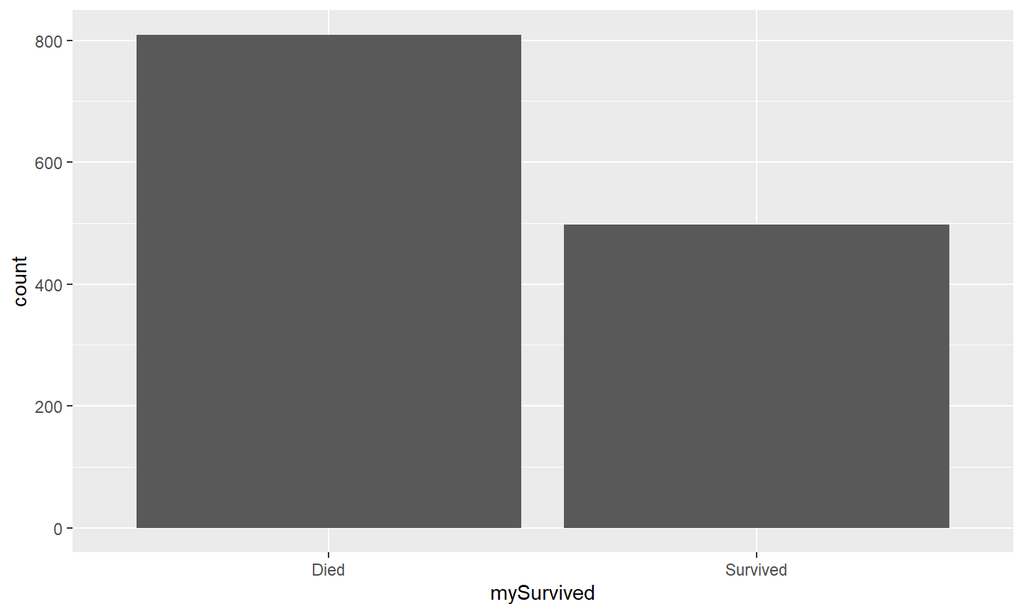

```r
ggplot(data = titanicData, aes(x = mySurvived)) + geom_bar()
```

## `ggplot2` barplots

- Generally: Save base object, then “add layers”

```r
g <- ggplot(data = titanicData, aes(x = mySurvived))
g + geom_bar()
```

## `ggplot2` barplots

- Generally: Save base object, then “add layers”

```r
g <- ggplot(data = titanicData, aes(x = mySurvived))
g + geom_bar()
```

- `aes()` defines visual properties of objects in the plot

`x = , y = , size = , shape = , color = , alpha = , ...`

- Cheat Sheet gives most common properties for a given `geom`

## `ggplot2` barplots

- Generally: Save base object, then “add layers”

```r
g <- ggplot(data = titanicData, aes(x = mySurvived))
g + geom_bar()
```

- `aes()` defines visual properties of objects in the plot

`x = , y = , size = , shape = , color = , alpha = , ...`

- Cheat Sheet gives most common properties for a given `geom`

`d + geom_bar()`

`x, alpha, color, fill, linetype, size, weight`

## `ggplot2` global and local aesthetics

`data` and `aes` can be set in two ways;

- ‘globally’ (for all layers) via the `ggplot` statement
- ‘locally’ (for just that layer) via the `geom`, `stat`, etc. layer

## `ggplot2` global and local aesthetics

`data` and `aes` can be set in two ways;

- ‘globally’ (for all layers) via the `ggplot` statement
- ‘locally’ (for just that layer) via the `geom`, `stat`, etc. layer

```r
#global
ggplot(data = titanicData, aes(x = mySurvived)) + geom_bar()
#local
ggplot() + geom_bar(data = titanicData, aes(x = mySurvived))
```

## `ggplot2` global and local aesthetics

`data` and `aes` can be set in two ways;

- ‘globally’ (for all layers) via the `ggplot` statement
- ‘locally’ (for just that layer) via the `geom`, `stat`, etc. layer

```r
#global
ggplot(data = titanicData, aes(x = mySurvived)) + geom_bar()
#local
ggplot() + geom_bar(data = titanicData, aes(x = mySurvived))
```

- To set an attribute that doesn’t depend on the data (i.e. `color = 'blue'`), generally place these outside of the `aes`

## `ggplot2` barplots

- Add better labels and a title (new layers, see cheat sheet!)

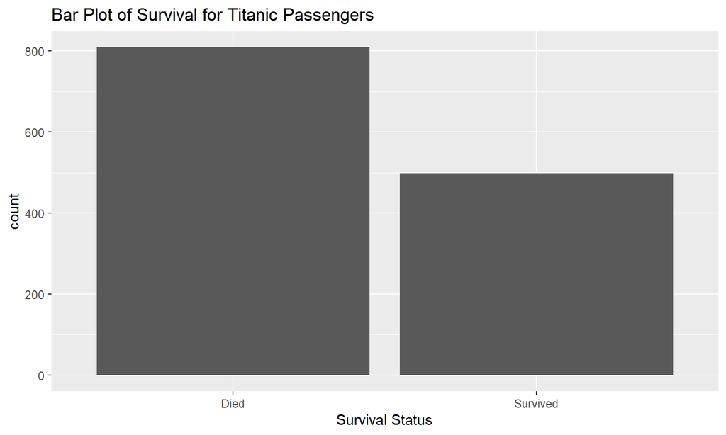

```r
ggplot(data = titanicData, aes(x = mySurvived)) +
  geom_bar() +
  labs(x = "Survival Status", title = "Bar Plot of Survival for Titanic Passengers")
```

## `ggplot2` stacked barplots

- **Stacked barplot** created by via `fill` aesthetic and same process
  - Create base object
  - Add geoms
  - Use aes to specify aspects of the plot

## `ggplot2` stacked barplots

- **Stacked barplot** created by via `fill` aesthetic
- Automatic assignment of colors, creation of legends, etc. for `aes` elements (except with `group`)

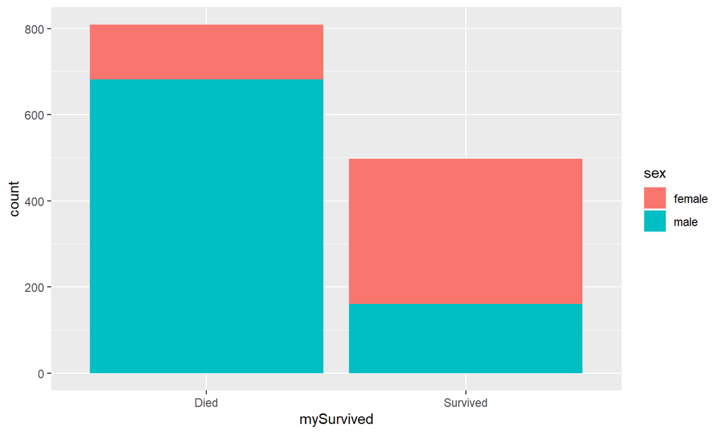

```r
ggplot(data = titanicData, aes(x = mySurvived, fill = sex)) + geom_bar()
```

## `ggplot2` labeling

- Add custom labels by adding more layers

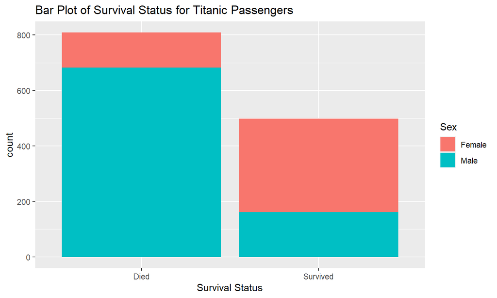

```r
ggplot(data = titanicData, aes(x = mySurvived, fill = sex)) +
  geom_bar() +
  labs(x = "Survival Status",
       title = "Bar Plot of Survival Status for Titanic Passengers") +
  scale_fill_discrete(name = "Sex", labels = c("Female", "Male"))
```

## `ggplot2` labeling

- Adjusting appropriate labeling via `scale_*_discrete`

`aes(x = survived, fill = sex)`

`scale_x_discrete(labels = c("Person Died", "Person Survived"))`

`scale_fill_discrete(name = "Sex", labels = c("Female","Male"))`

## `ggplot2` horizontal barplots

- Easy to rotate a plot with `coord_flip`

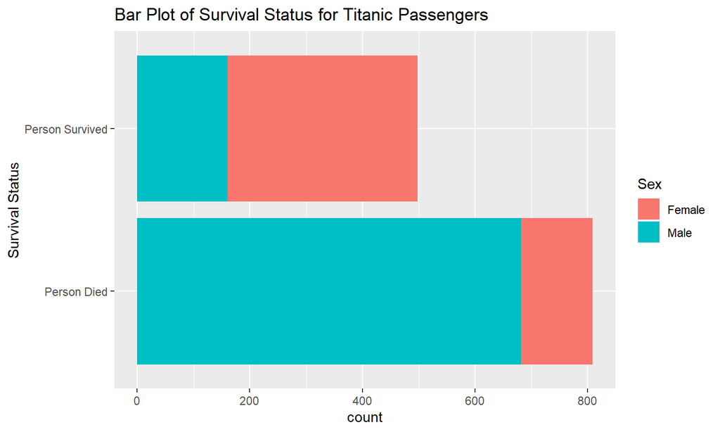

```r
ggplot(data = titanicData, aes(x = mySurvived, fill = sex)) + geom_bar() +
  labs(x = "Survival Status",
       title = "Bar Plot of Survival Status for Titanic Passengers") +
  scale_x_discrete(labels = c("Person Died", "Person Survived")) +
  scale_fill_discrete(name = "Sex", labels = c("Female", "Male")) +
  coord_flip()
```

## `ggplot2` stat vs geom layers

Note: Most geoms have a corresponding stat that can be used

`geom_bar(mapping = NULL, data = NULL, stat = "count", position = "stack", ..., width = NULL, binwidth = NULL, na.rm = FALSE, show.legend = NA, inherit.aes = TRUE)`

- Equivalent plots via:

```r
ggplot(data = titanicData, aes(x = survived, fill = sex)) + geom_bar()
ggplot(data = titanicData, aes(x = survived, fill = sex)) + stat_count()
```

## `ggplot2` stat vs geom layers

- Can modify the stat: if you have summary data, use `identity`

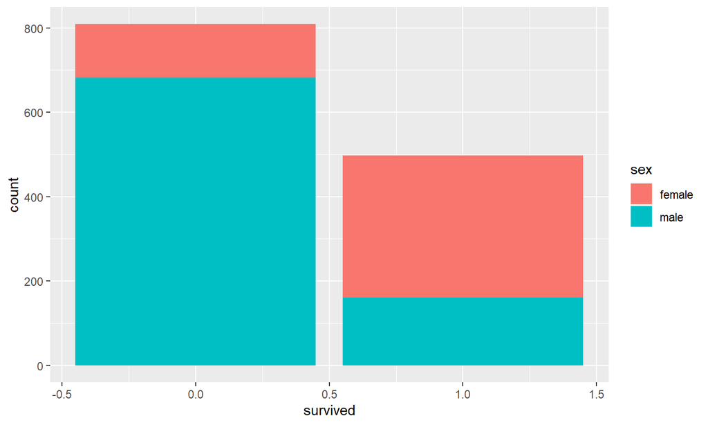

```r
sumData <- titanicData %>%
  group_by(survived, sex) %>%
  summarize(count = n())
ggplot(sumData, aes(x = survived, y = count, fill = sex)) +
  geom_bar(stat = "identity")
```

## `ggplot2` side-by-side barplots

- **Side-by-side barplot** created by via `position` aesthetic
  - `dodge` for side-by-side bar plot
  - `jitter` for continuous data with many points at same values
  - `fill` stacks bars and standardises each stack to have constant height
  - `stack` stacks bars on top of each other

## `ggplot2` side-by-side barplots

- **Side-by-side barplot** created by via `position` aesthetic

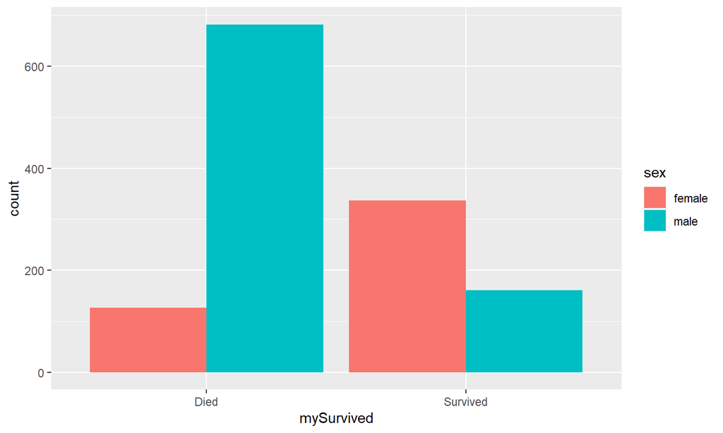

```r
ggplot(data = titanicData, aes(x = mySurvived, fill = sex)) +
  geom_bar(position = "dodge")
```

## `ggplot2` filled barplots

- `position = fill` stacks bars and standardises each stack to have constant height (especially useful with equal group sizes)

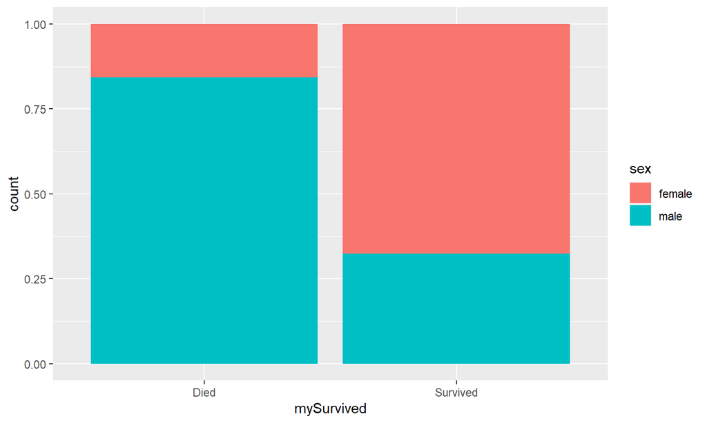

```r
ggplot(data = titanicData, aes(x = mySurvived, fill = sex)) +
  geom_bar(position = "fill")
```

## `ggplot2` faceting

How to create same plot for each `myEmbarked` value? Use **faceting**!

## `ggplot2` faceting

How to create same plot for each `myEmbarked` value? Use **faceting**!

`facet_wrap(~ var)` - creates a plot for each setting of `var`

- Can specify `nrow` and `ncol` or let R figure it out

## `ggplot2` faceting

How to create same plot for each `myEmbarked` value? Use **faceting**!

`facet_wrap(~ var)` - creates a plot for each setting of `var`

- Can specify `nrow` and `ncol` or let R figure it out

`facet_grid(var1 ~ var2)` - creats a plot for each combination of `var1` and `var2`

- `var1` values across rows
- `var2` values across columns
- Use `. ~ var2` or `var1 ~ .` to have only one row or column

## `ggplot2` faceting

How to create same plot for each `myEmbarked` value? Use **faceting**!

- `facet_wrap(~ var)` - creates a plot for each setting of `var`

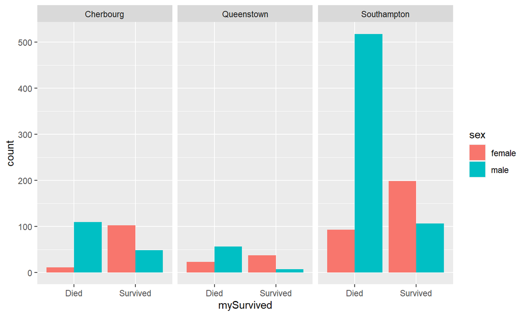

```r
ggplot(data = titanicData, aes(x = mySurvived)) +
  geom_bar(aes(fill =sex), position = "dodge") +
  facet_wrap(~ myEmbarked)
```

## `ggplot2` Plotting Recap

General `ggplot` things:

- Can set local or global `aes`
- Modify titles/labels by adding more layers
- Faceting (multiple plots) via `facet_grid` or `facet_wrap`
- Only need `aes` if setting a mapping value that is dependent on the data (or you want to create a custom legend!)

## Quick Examples

- Go to the [course files page](https://jbpost2.github.io/Basics-of-R-for-Data-Science-and-Statistics/CourseFiles.html) and try Exercise 10 - Bar Plots

## `ggplot2` Plotting: Numeric Variables

Numeric variables - generally, describe distribution via a histogram or boxplot!

Same process:

- Create base object
- Add geoms
- Use aes to specify aspects of the plot

## `ggplot2` smoothed histogram

- **Kernel Smoother** - Smoothed version of a histogram
- Common `aes` values (from cheat sheet):

`c + geom_density(kernel = "gaussian")`

`x, y, alpha, color, fill, group, linetype, size, weight`

- Only `x =` is really needed

## `ggplot2` smoothed histogram

- **Kernel Smoother** - Smoothed version of a histogram

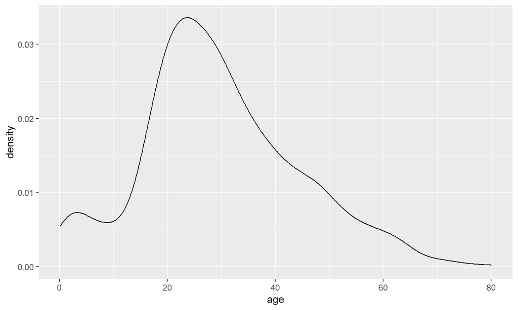

```r
g <- ggplot(titanicData, aes(x = age))
g + geom_density()
```

## `ggplot2` smoothed histogram

- **Kernel Smoother** - Smoothed version of a histogram
- `fill` a useful aesthetic!

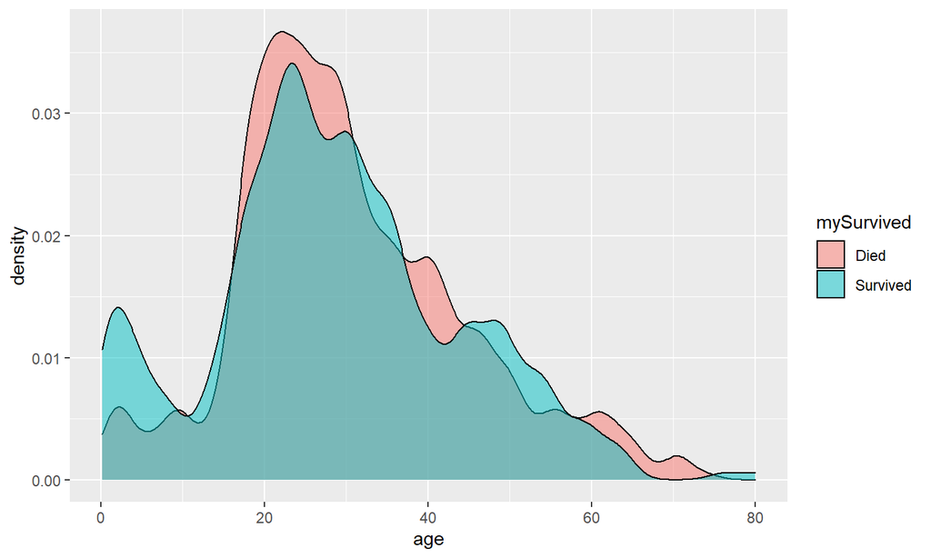

```r
g + geom_density(adjust = 0.5, alpha = 0.5, aes(fill = mySurvived))
```

## `ggplot2` smoothed histogram

- **Kernel Smoother** - Smoothed version of a histogram
- recall `position` choices of `dodge`, `jitter`, `fill`, and `stack`

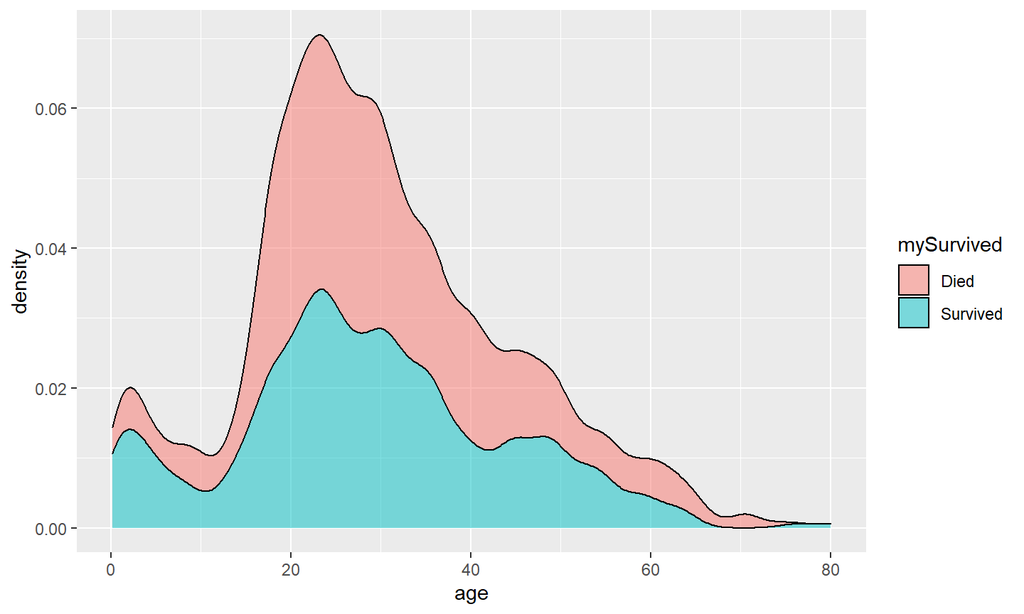

```r
g + geom_density(adjust = 0.5, alpha = 0.5, position = "stack", aes(fill = mySurvived))
```

## `ggplot2` boxplots

- **Boxplot** - Provides the five number summary in a graph
- Common `aes` values (from cheat sheet):

`f + geom_boxplot()`

`x, y, lower, middle, upper, ymax, ymin, alpha, color, fill, group, linetype, shape, size, weight`

- Only `x =, y =` are really needed

## `ggplot2` boxplots

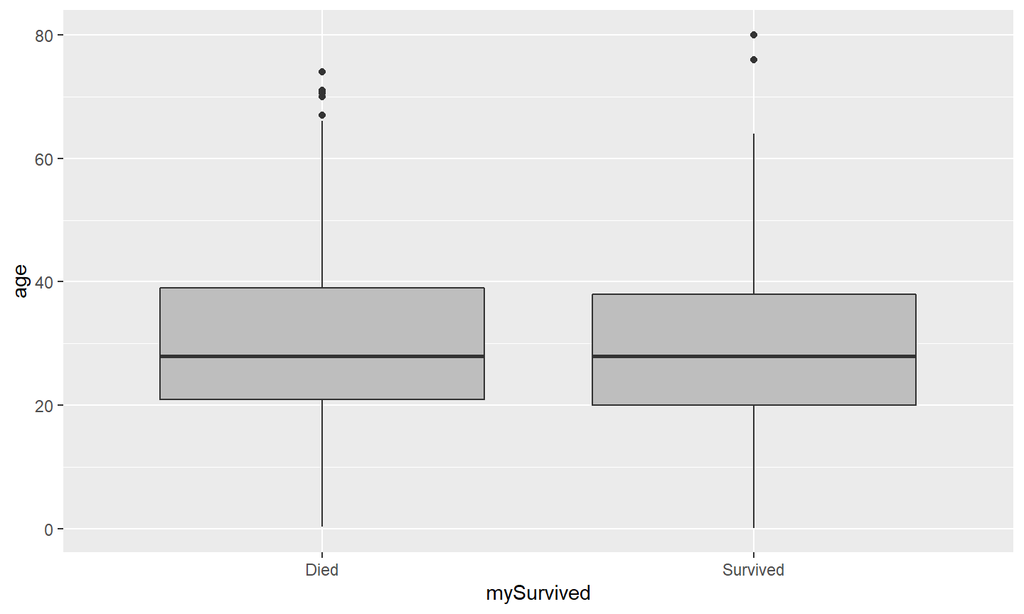

```r
g <- ggplot(titanicData, aes(x = mySurvived, y = age))
g + geom_boxplot(fill = "grey")
```

## `ggplot2` boxplots with points

- Can add data points (jittered) to see shape of data better (or use violin plot)

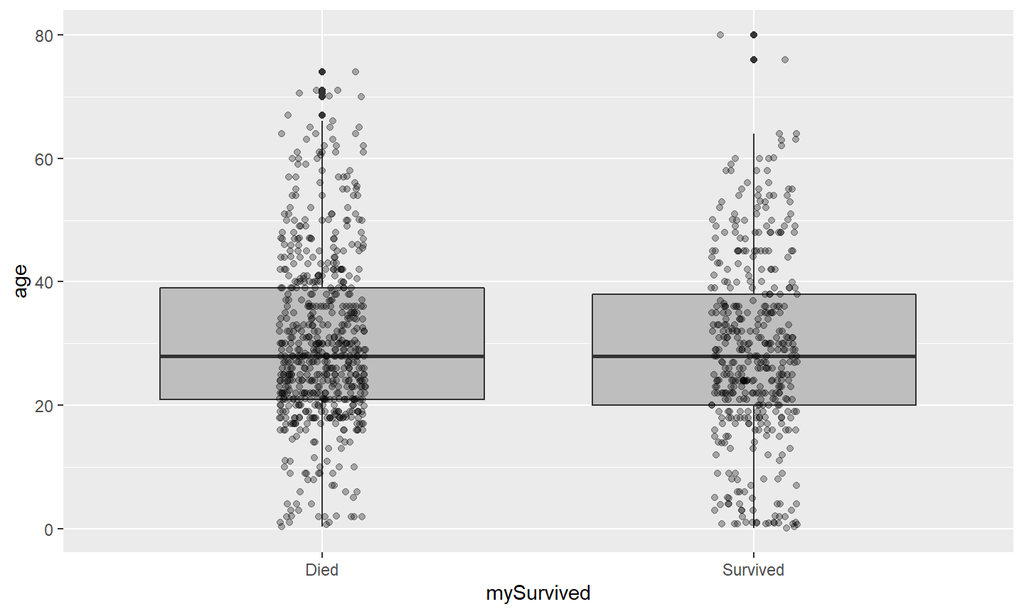

```r
g +
  geom_boxplot(fill = "grey") +
  geom_jitter(width = 0.1, alpha = 0.3)
```

## `ggplot2` boxplots with points

- Order of layers important!

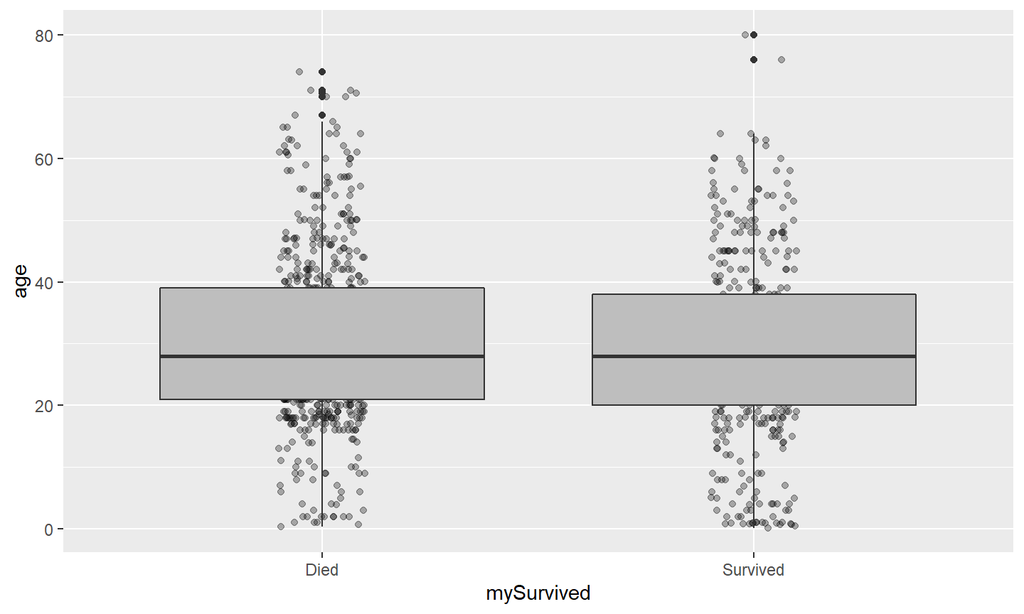

```r
g +
  geom_jitter(width = 0.1, alpha = 0.3) +
  geom_boxplot(fill = "grey")
```

## `ggplot2` faceting

- Can `facet` easily!

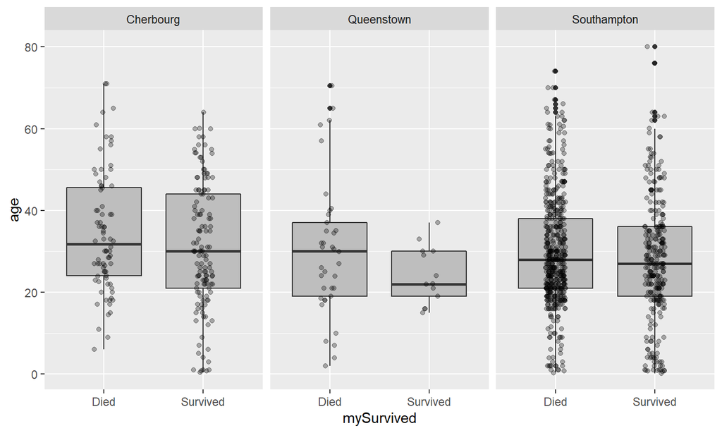

```r
g + geom_boxplot(fill = "grey") +
  geom_jitter(width = 0.1, alpha = 0.3) +
  facet_wrap(~ myEmbarked)
```

## `ggplot2` scatter plots

Two numerical variables

- **Scatter Plot** - graphs points corresponding to each observation
- Common `aes` values (from cheat sheet):

`e + geom_point()`

`x, y, alpha, color, fill, shape, size, stroke`

- Only `x =, y =` are really needed

## `ggplot2` scatter plots

- **Scatter Plot** - graphs points corresponding to each observation

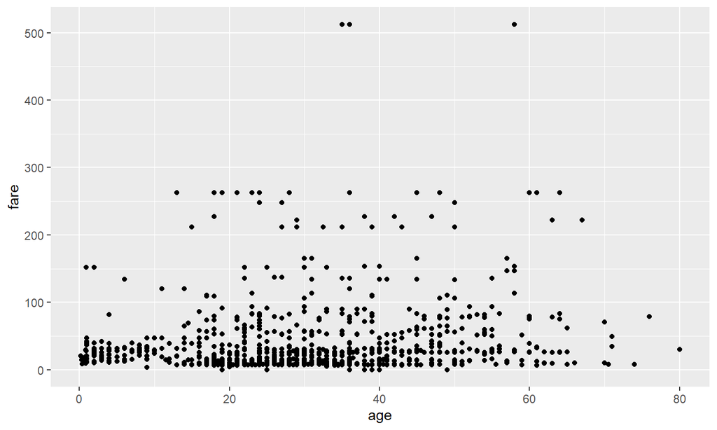

```r
g <- ggplot(titanicData, aes(x = age, y = fare))
g + geom_point()
```

## `ggplot2` scatter plots with trend line

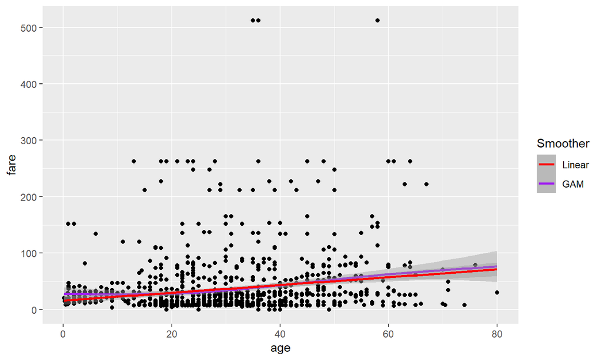

```r
g + geom_point() +
  geom_smooth(aes(col = "loess")) +
  geom_smooth(method = lm, aes(col = "linear")) +
  scale_colour_manual(name = 'Smoother', values =c('linear'='red', 'loess'='purple'),
                      labels = c('Linear','GAM'), guide = 'legend')
```

## `ggplot2` scatter plots with text

- May want to add value of correlation to plot
- `paste()` or `paste0()` handy

```r
paste("Hi", "What", "Is", "Going", "On", "?", sep = " ")
```

```
## [1] "Hi What Is Going On ?"
```

```r
paste("Hi", "What", "Is", "Going", "On", "?", sep = ".")
```

```
## [1] "Hi.What.Is.Going.On.?"
```

```r
paste0("Hi", "What", "Is", "Going", "On", "?")
```

```
## [1] "HiWhatIsGoingOn?"
```

## `ggplot2` scatter plots with text

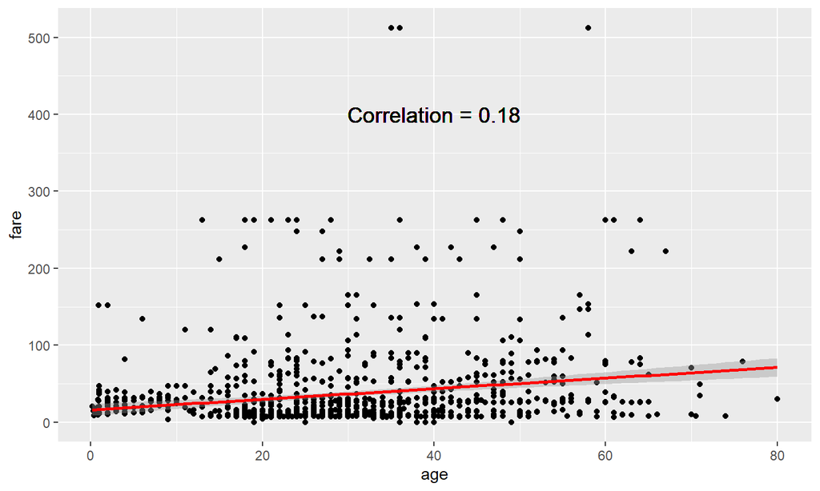

```r
correlation <- cor(titanicData$fare, titanicData$age, use = "complete.obs")
g + geom_point() +
  geom_smooth(method = lm, col = "Red") +
  geom_text(x = 40, y = 400, size = 5,
            label = paste0("Correlation = ", round(correlation, 2)))
```

## `ggplot2` scatter plots with text points

- Text for points with `geom_text`

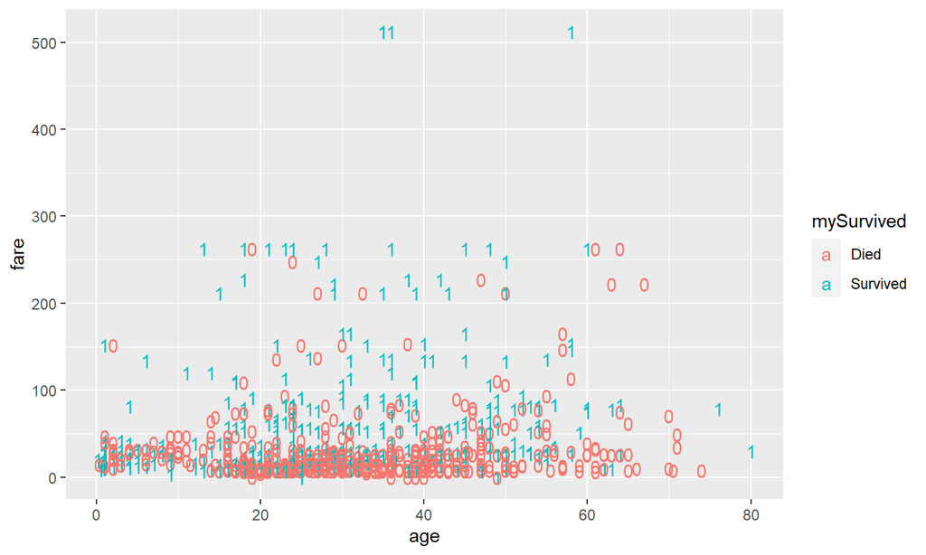

```r
g + geom_text(aes(label = survived, color = mySurvived))
```

## `ggplot2` faceting

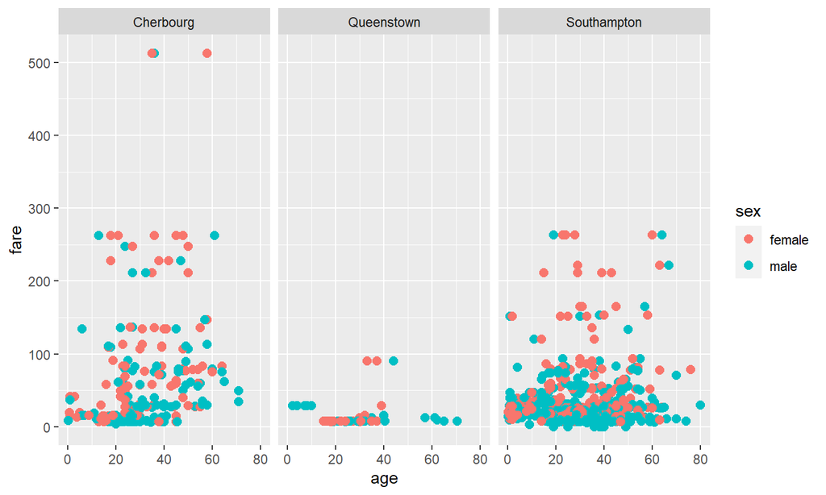

```r
g + geom_point(aes(color = sex), size = 2.5) +
  facet_wrap(~ myEmbarked)
```

## `ggpairs`

Many extension packages that do nice things!

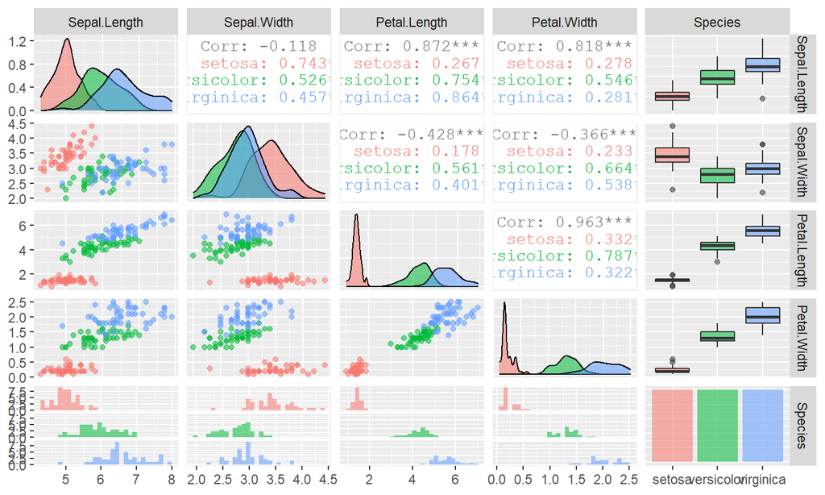

```r
library(GGally) #install GGally if needed
ggpairs(iris, aes(colour = Species, alpha = 0.4))
```

## `ggplot2` Plotting: Numeric variables

Numeric variable - entries are a numerical value where math can be performed

Most common plots:

- Histogram (`geom_hist`), Density (`geom_density`)
- Boxplot (`geom_boxplot`), Violin plot (`geom_violin`)
- Scatter plot (`geom_point`), Smoothers (`geom_smooth`)
- Jittered points (`geom_jitter`)
- Text on plot (`geom_text`)

## `ggplot2` Plotting Recap

General `ggplot` things:

- Can set local or global `aes`
- Modify titles/labels by adding more layers
- Use either stat or geom layer
- Faceting (multiple plots) via `facet_grid` or `facet_wrap`
- Only need `aes` if setting a mapping value that is dependent on the data (or you want to create a custom legend!)
- `esquisse` is a [great package for exploring ggplot2](https://cran.r-project.org/web/packages/esquisse/vignettes/get-started.html)!

## Quick Examples

- Go to the [course files page](https://jbpost2.github.io/Basics-of-R-for-Data-Science-and-Statistics/CourseFiles.html) and try Exercise 11 - ggplot